# ggplot2 Tutorial

### 5.7 기타 ggplot2의 문법 요소

ggplot2에는 지금까지 설명한 문법 요소 외에도 통계 변환(stat), 위치 조정(position), 스케일 변환(scale), 좌표축 변환(coord), 테마(theme) 등의 요소가 있다. ggplot2를 사용하여 복잡한 시각화를 수행하려면 이러한 문법 요소에 대한 체계적 이해와 습득이 필요하다. 그러나 이 책은 데이터 시각화 전반을 소개하는 것이 목적이 아니기 때문에, 통계데이터 분석을 위한 그래프를 그릴 때 이러한 문법 요소가 필요하면 그 요소를 단편적으로 설명할 예정이다. 그러므로 좀 더 ggplot2 그래프에 대한 체계적인 이해를 원하는 독자는 R 프로그래밍의 ggplot2를 이용한 데이터 시각화를 참조하기 바란다.

이 절의 나머지 부분에서는 나머지 문법 요소 중 그래프의 외양을 변경하는 매우 간단한 한 가지 문법 요소만 살펴보도록 한다.

#### 5.7.1 그래프 레이블을 조정하기

`ggplot2` 패키지의 `labs()` 함수는 그래프의 제목, 좌표축 이름, 범례의 이름을 쉽게 바꿀 수 있게 해준다. 다음은 `mpg` 데이터의 배기량과 고속도로 연비의 산점도를 자동차 종류 별로 다른 색상으로 그린 예이다. 그런데 `ggplot2`에서는 기본적으로 좌표축 레이블과 색상의 범례 레이블로, 좌표축과 색상에 매핑된 열의 이름을 사용한다. 그리고 그래프에 제목은 달지 않는다.

```r
ggplot(mpg, aes(x = displ, y = hwy, color = class)) + geom_point()
```

[output not shown]

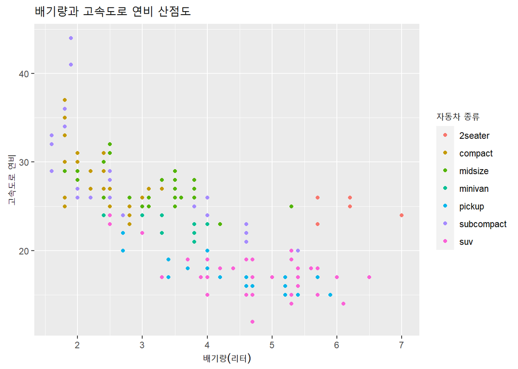

```r
ggplot(mpg, aes(x = displ, y = hwy, color = class)) +
  geom_point() +
  labs(title = '배기량과 고속도로 연비 산점도',
       x = '배기량(리터)',
       y = '고속도로 연비',
       color = '자동차 종류')
```

`labs()` 함수는 ggplot2 그래프에 `+` 연산으로 결합하여 사용되면, 그래픽 속성 매핑에 사용된 `x`, `y`, `color` 인수에 사용할 이름을 지정하면 된다. 그래프의 제목을 지정하려면 `title`이라는 인수를 사용한다.